# Part 2: Descriptive Statistics

### Measures of Dispersion

Range, Mean Absolution Difference, Variance and Standard Deviation

### Measures of Dispersion

Average alone is not sufficient to summarize and describe our data.

Consider the following 5 sample datasets.

Although the data values are very different, they all have the same average.

|  | **S1** | **S2** | **S3** | **S4** | **S5** |
| --- | --- | --- | --- | --- | --- |
|  | 100 | 200 | 0 | -600 | -2000 |
|  | 200 | 200 | 600 | 600 | 2500 |
|  | 300 | 200 | 0 | 600 | 100 |
| **Average** | **200.00** | **200.00** | **200.00** | **200.00** | **200.00** |

### Measures of Dispersion – The Range

The **Range** is the simplest measure of dispersion, it is the difference between the maximum value and the minimum value in a data set:

**Range = Maximum Value – Minimum Value**

Going back to the previous sample datasets, we can see that they have the same average, but their ranges are very different.

|  | **S1** | **S2** | **S3** | **S4** | **S5** |
| --- | --- | --- | --- | --- | --- |
|  | 100 | 200 | 0 | -600 | -2000 |
|  | 200 | 200 | 600 | 600 | 2500 |
|  | 300 | 200 | 0 | 600 | 100 |
| Average | 200.00 | 200.00 | 200.00 | 200.00 | 200.00 |
| **Range** | **200.00** | **0.00** | **600.00** | **1200.00** | **4500.00** |

Therefore, using the **Range** with the **Average** helped us to better describe and summarize our data (Better Understand Our Data).

**However, the Range is sensitive to Outliers. Consider the following sample dataset:**

Data = ($1.00, $2.00, $3.00, $3.00, $3.00, $1.00, $100.00)

Most of the data values are around $3, yet their Range is $99.00

### Measures of Dispersion - The Mean Absolute Deviation

A good measure of dispersion should consider differences of all observations from the mean.

If we simply average all differences from the mean, the positives and the negatives will cancel out, even though they both contribute to dispersion, and the resulting average will equal zero.

The **mean absolute deviation** (MAD) is an average of the absolute differences between the observations and the mean.

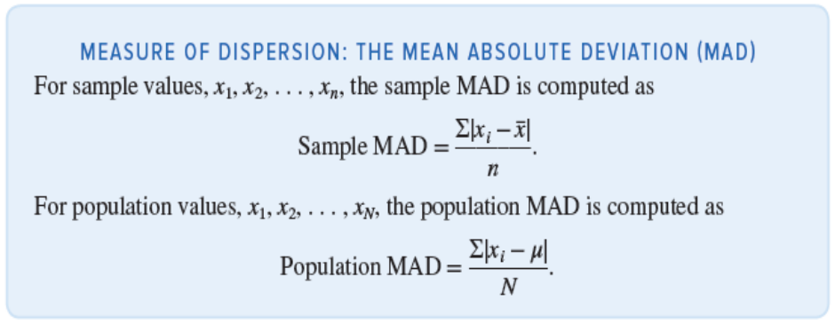

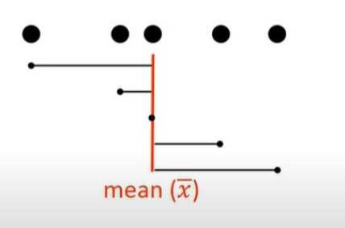

### Measures of Dispersion - The Variance and the Standard Deviation

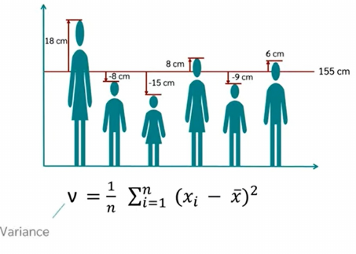

MAD weights large and small differences equally.

Better measures are the **variance** and the **standard deviation.**

Instead of calculating the average of the absolute differences from the mean, as in MAD, we calculate the average of the squared differences from the mean.

The squaring of differences from the mean emphasizes larger differences more than smaller ones.

The variance has squared units, therefore, to return the values to their original units of measurement, we compute the square root of the variance, which gives us the standard deviation.

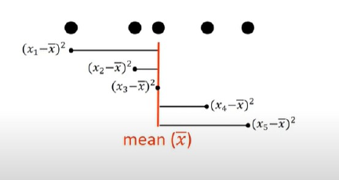

### Measures of Dispersion - The Variance and the Standard Deviation

#### Sample

For **sample** values $x_1, x_2, \ldots, x_n$, the sample variance $s^2$ and the sample standard deviation $s$ are computed as

$$s^2 = \frac{\sum_{i=1}^{n}(x_i-\bar{x})^2}{n-1}
\qquad\text{and}\qquad
s = \sqrt{s^2}.$$

#### Population

For **population** values $x_1, x_2, \ldots, x_N$, the population variance $\sigma^2$ (the Greek letter sigma, squared) and the population standard deviation $\sigma$ are computed as

$$\sigma^2 = \frac{\sum_{i=1}^{N}(x_i-\mu)^2}{N}
\qquad\text{and}\qquad
\sigma = \sqrt{\sigma^2}.$$

**Note:** The sample variance uses $n-1$ rather than $n$ in the denominator to ensure that the sample variance is an unbiased estimator for the population variance, a topic discussed in Chapter 8.

### Excel Functions for Measuring Dispersion

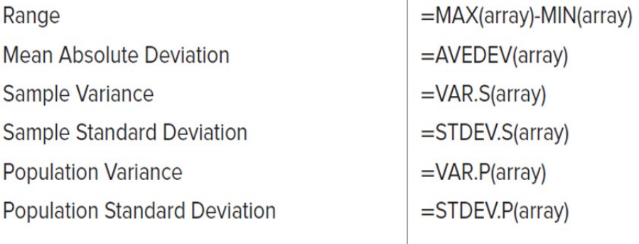

### Practical Exercise

Use the students.xlsx file to find the Range, MAD, Variance and Standard Deviation for the age column.

Note: In Excel you can filter out rows by converting a Range to a Table and using the filtering list in each header of a column.

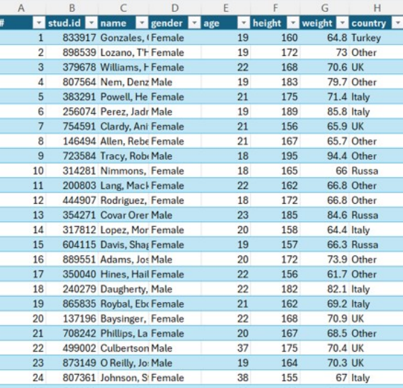

#### R equivalent (added)

```r
# diff(range()) gives maximum minus minimum; mean(abs()) calculates mean absolute deviation.
# var() and sd() use the sample denominator n-1; R's mad() instead computes median absolute deviation.
age <- students$age
c(range = diff(range(age)), mean_absolute_deviation = mean(abs(age - mean(age))),
  sample_variance = var(age), sample_standard_deviation = sd(age))
```

```
                    range   mean_absolute_deviation           sample_variance
                46.000000                  2.902923                 36.785568
sample_standard_deviation
                 6.065111
```

### Practical Exercise: using Excel’s data analysis tools option

Select: Data > Data Analysis > Descriptive Statistics > OK.

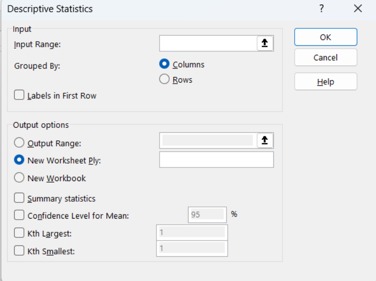

### The Coefficient of Variation

### The Coefficient of Variation

In some instances, we need to compare the variability of two or more data sets that have different means or different units of measurement.

Consider the following example:

We cannot tell which dataset has more variance in its values since both datasets have the same standard deviation.

|  | **DS1** | **DS2** |
| --- | --- | --- |
|  | $10 | $1010 |
|  | $20 | $1020 |
|  | $30 | $1030 |
|  | $40 | $1040 |
|  | $50 | $1050 |
| **Average** | **$30** | **$1030** |
| **Standard Deviation** | **15.81** | **15.81** |

### The Coefficient of Variation

For such cases, we can use the Coefficient of Variation Measure which serves as a relative measure of dispersion.

It can be calculated by dividing a data set’s standard deviation by its mean:

When comparing two datasets, the dataset that have larger coefficient of variation indicates that its values varies more than the other dataset. Therefore, it is less stable or less uniform.

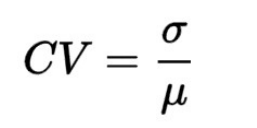

### The Coefficient of Variation

Going back to the previous example, we can calculate the coefficient of variation for both sets to help us in determining which dataset has more variability in its values.

Using the Coefficient of Variation, we can tell that DS1 varies more than DS2, and that DS2 is more stable than DS1.

[output not shown]

#### R equivalent (added)

```r
# c() creates the exact two datasets shown in the original table; sd() uses the sample denominator n-1.
# sd()/mean() expresses CV as a ratio, without multiplying by 100; these means are positive.
DS1 <- c(10, 20, 30, 40, 50)
DS2 <- c(1010, 1020, 1030, 1040, 1050)
c(DS1 = sd(DS1) / mean(DS1), DS2 = sd(DS2) / mean(DS2))
```

```
       DS1        DS2
0.52704628 0.01535086
```

### Coefficient of Variation Uses in Finance

In finance, the coefficient of variation is used to measure the risk per unit of return.

We can use the coefficient of variation to determine which stock is more stable:

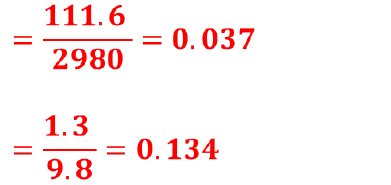

## Measures of Association

Covariance and Coefficient of Correlation

### Measures of Association

We previously introduced the idea of a scatter plots to visually assess whether two variables had some type of linear relationship.

In this section, we present two numerical measures of association that quantify the direction and strength of the linear relationship between two variables, x and y.

These two numerical values are the Covariance and the Correlation.

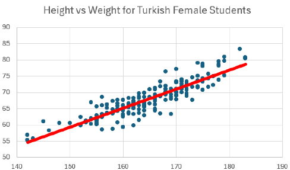

Note: Covariance and Correlation works when the relation between the two variables is LINEAR.

### Covariance

Covariance measures the joint variability of two random variables.

Indicates the direction of the linear relationship between variables.

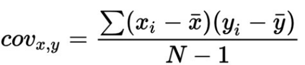

Positive Covariance: X and Y move in the same direction.

Negative Covariance: X and Y move in opposite directions.

Zero Covariance: No linear relationship between X and Y.

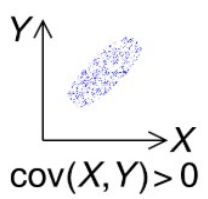

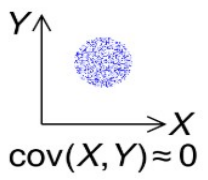

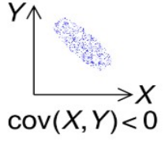

### Limitations of Covariance

Covariance is sensitive to the units of X and Y.

Changing units changes the covariance value, making direct comparisons difficult.

|  | Height m | Height cm | Weight KG |
| --- | --- | --- | --- |
|  | 1.6 | 160 | 55 |
|  | 1.7 | 170 | 68 |
|  | 1.8 | 180 | 74 |
| **Covariance** | **.95** | **95** | Which one is bigger? |
| **Correlation** | **.98** | **.98** |  |

### The Correlation Coefficient

Correlation coefficient can be used to determine the Direction and the Strength of a relationship between two numerical variables.

The correlation coefficient is a dimensionless metric and its value ranges from -1 to +1.

The closer it is to +1 or -1, the more closely the two variables are related.

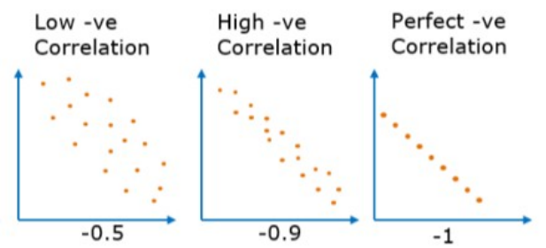

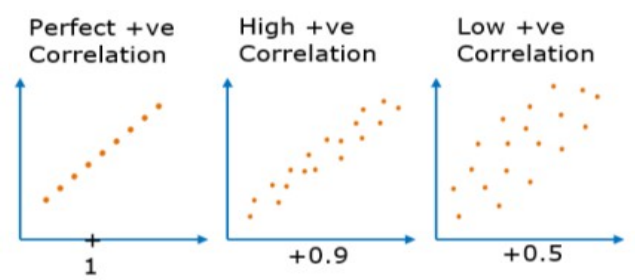

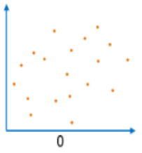

### Differences between Covariance and Correlation

| Covariance | Correlation |
| --- | --- |
| Covariance indicates the direction of the linear relationship between variables. | Correlation measures both the strength and the direction of the linear relationship between two variables. |
| Covariance value can vary between -∞ and +∞ | Correlation value ranges between -1 and +1 |
| Covariance unit is based on the product of the units of the two variables. | Correlation is dimensionless, i.e. It’s a unit-free measure of the relationship between variables. |

### Practical Exercise

Use the students.xlsx file:

Compute the covariance and correlation between heights and weights of the students.

Compute the covariance and correlation between heights and ages of the students.

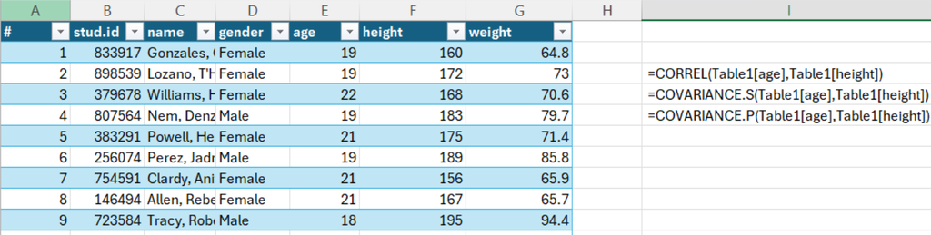

#### R equivalent (added)

```r
# cov() calculates sample covariance and cor() calculates Pearson's linear correlation by default.
# use="complete.obs" omits pairs with missing values; units remain cm, kg, and years.
cov(students$height, students$weight, use = "complete.obs")
```

```
[1] 89.89815
```

```r
cor(students$height, students$weight, use = "complete.obs")
```

```
[1] 0.9398042
```

```r
cov(students$height, students$age, use = "complete.obs")
```

```
[1] -0.8861261
```

```r
cor(students$height, students$age, use = "complete.obs")
```

```
[1] -0.01318906
```

### Practical Exercise

We can also use the Data Analysis add-in for this purpose.

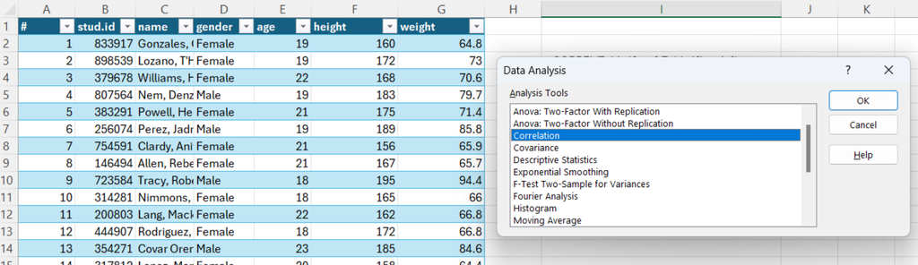

## Measures of Distribution

Symmetry and Skewness

### Skewness

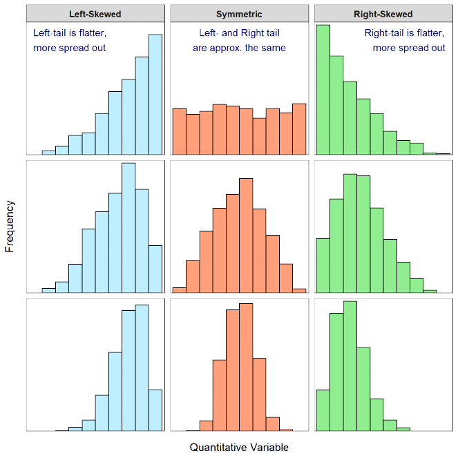

**Definition**: Skewness is a measure of the asymmetry of the probability distribution of a real-valued random variable about its mean.

**Key Point**: Indicates whether the data are spread out more to one side of the mean.

**Positive Skewness (Right-skewed): Tail is longer on the right side of the distribution. Mean is greater than the median.**

**Negative Skewness (Left-skewed**): Tail is longer on the left side of the distribution. Mean is less than the median.

Symmetrical Distribution: Skewness is around 0, indicating no skew.

Use histograms or density plots to illustrate examples of positively skewed, negatively skewed, and symmetrical distributions.

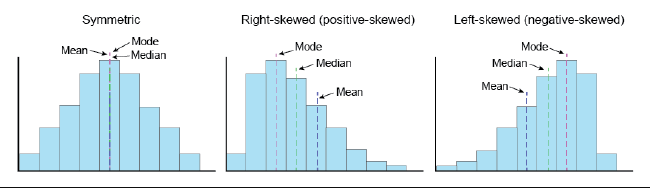

### Skewness Coefficient

A positive skewness coefficient implies that extreme values are concentrated in the right tail of the distribution, pulling the mean up, relative to the median and the bulk of values lie to the left of the mean.

Similarly, a negative skewness coefficient implies that extreme values are concentrated in the left tail of the distribution, pulling the mean down, relative to the median, and the bulk of values lie to the right of the mean.

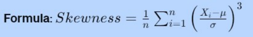

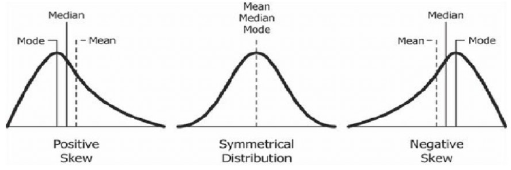

**A skewness value greater than 1 or less than -1 indicates a highly skewed distribution.**

**A value between 0.5 and 1 or -0.5 and -1 is moderately skewed.**

**A value between -0.5 and 0.5 indicates that the distribution is fairly symmetrical.**

**A skewness coefficient of zero indicates that the values are evenly distributed on both sides of the mean.**

### Practical Example

Using the students.xlsx file, find the Skewness value for the “age” column.

You can use Excel’s skew() function to calculate the skewness for a sample, and the skew.p() function to calculate the skewness for a population.

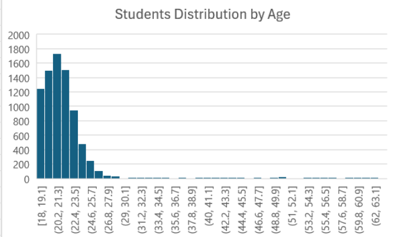

#### R equivalent (added)

```r
# length() supplies n; sum() adds cubed standardized deviations, using sample sd() with n-1.
# n/((n-1)*(n-2)) gives adjusted sample skewness, corresponding to Excel SKEW for n>2.
age <- students$age
n <- length(age)
n / ((n - 1) * (n - 2)) * sum(((age - mean(age)) / sd(age))^3)
```

```
[1] 4.427823
```

### Practical Exercise: using Excel’s data analysis tools option

Select: Data > Data Analysis > Descriptive Statistics > OK.

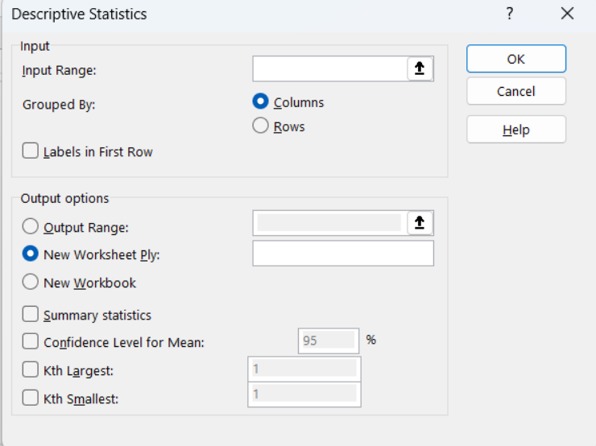

## Percentiles, Quartiles and Boxplots

### Percentiles

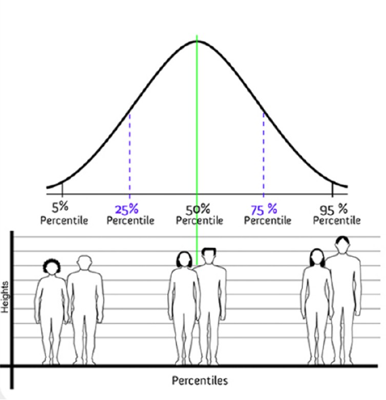

A **percentile** is a measure that helps us understand the position or relative standing of a particular value within a dataset.

Percentiles help us divide the data into equal-sized groups and determine the position of a value within those groups.

For example, if someone's score is at the 80th percentile, it means they performed better than 80% of the people in the dataset.

Percentiles provide insights into how a specific value compares to others, allowing us to assess performance, rankings, or distributions.

They are commonly used in various fields, such as education, healthcare, and finance, to understand and communicate data in a meaningful way.

### Practical Exercise

Using the students.xlsx file, find the 90% Percentile value for the “height” column.

You can use percentile.inc or percentile.exc to compute percentiles in Excel.

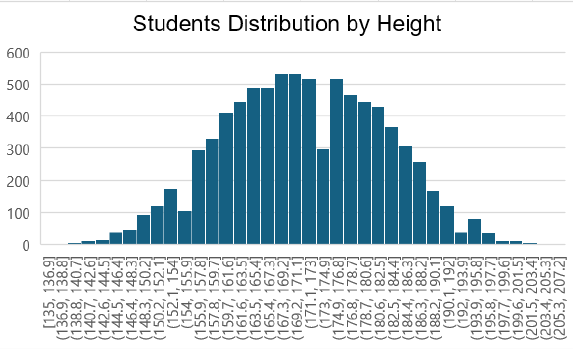

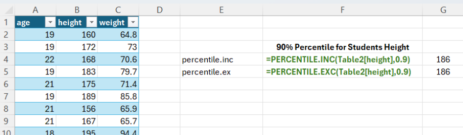

#### R equivalent (added)

```r
# quantile() finds the requested percentile; probs=0.90 means the 90th percentile of height in cm.
# type=7 matches Excel PERCENTILE.INC; type=6 matches PERCENTILE.EXC for this sample and probability.
quantile(students$height, probs = 0.90, type = 7)
```

```
90%
186
```

```r
quantile(students$height, probs = 0.90, type = 6)
```

```
90%
186
```

### Quartiles

A Quartile divides a sorted data set into 4 equal parts, so that each part represents ¼ of the data set.

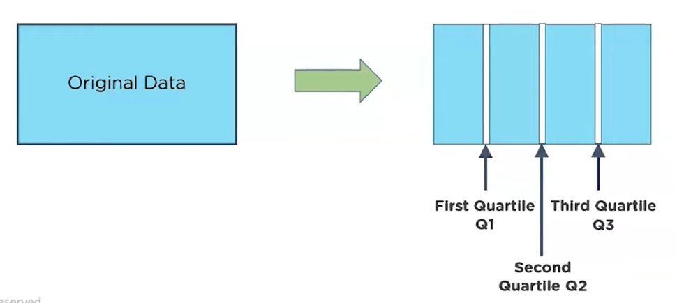

### Practical Exercise

Using the students.xlsx file, find the 1<sup>st</sup> and the 2<sup>nd</sup> quartiles for the “height” column.

You can use quartile.inc or quartile.exc to compute percentiles in Excel.

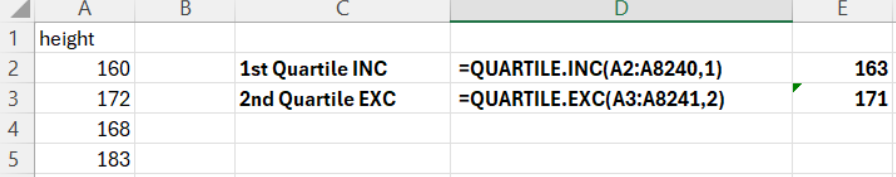

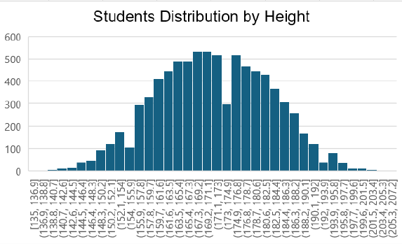

#### R equivalent (added)

```r
# quantile(probs=c(0.25,0.50)) returns the first and second quartiles of height in cm.
# type=7 uses Excel's inclusive convention; type=6 uses its exclusive convention for these probabilities.
quantile(students$height, probs = c(0.25, 0.50), type = 7)
```

```
25% 50%
163 171
```

```r
quantile(students$height, probs = c(0.25, 0.50), type = 6)
```

```
25% 50%
163 171
```

### Boxplots – Box and Whiskers Plots

A boxplot (box-and-whisker plot) is a standardized way of displaying the distribution of data based on a five number summary.

The five number summary include the minimum value (Min), quartiles (Q1, Q2, and Q3), and the maximum value (Max).

Boxplots are useful in showing us the range and the skewness of our data as well as outliers.

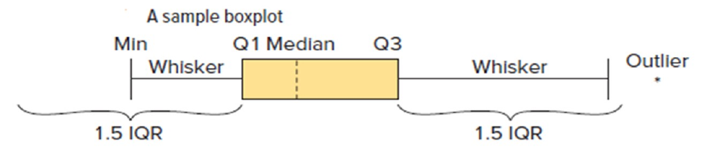

### Practical Exercise

Use the students.xlsx file:

Create a box plot that compares the height of male students vs female students.

Create a box plot that compares the height of Turkish male students vs Russian male students.

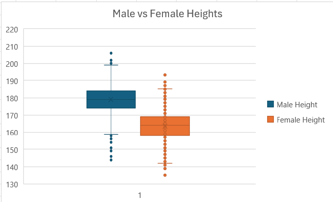

#### R equivalent (added)

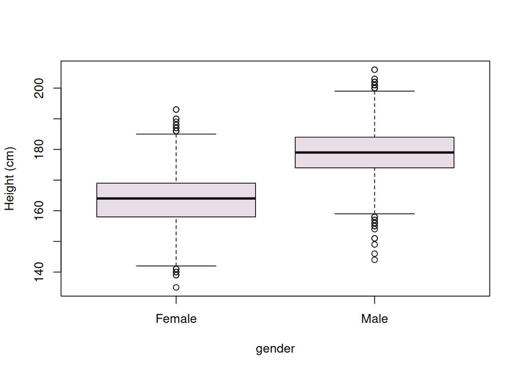

```r
# boxplot(height~gender) compares groups; whiskers extend to the last data within 1.5 IQR of the hinges.
# subset() selects Turkish/Russian males; R's default boxplot hinges can differ from type-7 quartiles.
boxplot(height ~ gender, data = students, ylab = "Height (cm)", col = "#E9DDE7")
```

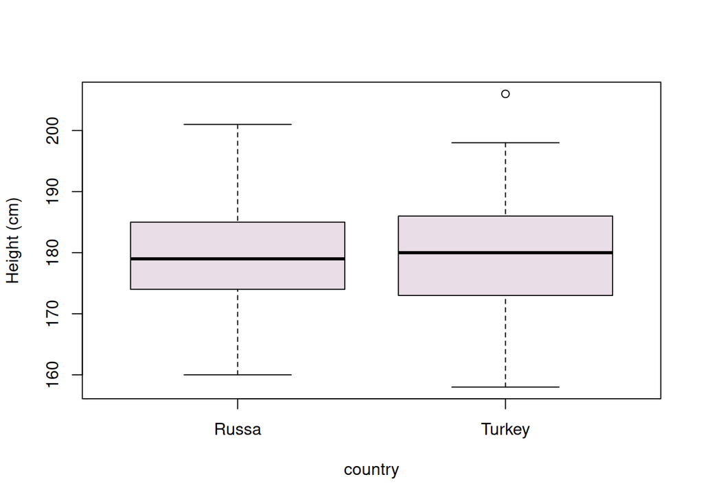

```r
# The source spells Russia as "Russa"; match that original label without changing the data.
males <- subset(students, gender == "Male" & country %in% c("Turkey", "Russa"))
boxplot(height ~ country, data = males, ylab = "Height (cm)", col = "#E9DDE7")
```

### Outliers

An outlier is an observation that lies an abnormal distance from other values in a random sample from a population.

We can identify potential outliers using Histograms, scatter plots, boxplots…etc.

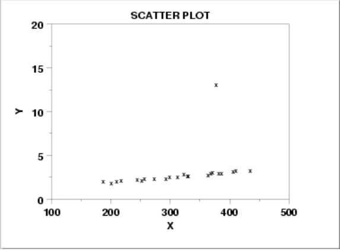

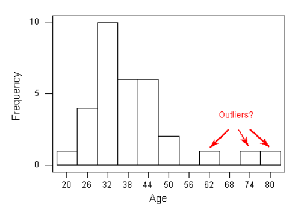

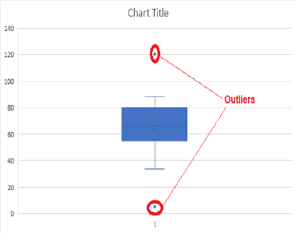

### The Interquartile Range (IQR)

The IQR is like the range, and it shows how the data is spread about the median.

It is less susceptible than the range to outliers and can, therefore, be more helpful.

The IQR is calculated according to the following formula:

IQR = Q3 – Q1.

### Using the IQR to Find Outliers

Using the IQR to find potential outliers:

Calculate the IQR for the data.

Multiply the interquartile range (IQR) by 1.5 (a constant used to discern outliers).

Add the (1.5 x (IQR)) to the third quartile, any number greater than this is a suspected outlier.

Subtract the (1.5 x (IQR)) from the first quartile, any number less than this is a suspected outlier.

However, any potential outlier obtained by the interquartile method should be examined in the context of the entire set of data.

We should always follow up our outlier analysis by studying the resulting outliers to see if they make sense.

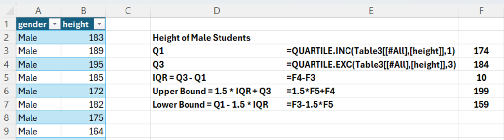

#### R equivalent (added)

```r
# quantile(type=7) supplies inclusive quartiles; the 1.5-IQR fences flag values for investigation.
# sum() counts TRUE flags and does not remove observations; these age fences are measured in years.
q <- quantile(students$age, probs = c(0.25, 0.75), type = 7)
iqr <- q[2] - q[1]
lower <- q[1] - 1.5 * iqr
upper <- q[2] + 1.5 * iqr
c(lower_fence = unname(lower), upper_fence = unname(upper))
```

```
lower_fence upper_fence
       15.5        27.5
```

```r
sum(students$age < lower | students$age > upper)
```

```
[1] 429
```

### Impacts of Outliers

**1. Negative Impacts**

Influence on Measures of Central Tendency: A single extreme outlier can pull the mean in its direction, making it unrepresentative of the majority of the data.

Skewing Data Distributions: Positive outliers can result in right-skewed distributions, while negative outliers can result in left-skewed distributions. This can affect the interpretation of the data.

Misleading Summary Statistics: Outliers can distort the interpretation of summary statistics.

Impact on Hypothesis Testing: Outliers can affect the results of hypothesis tests. They can lead to incorrect conclusions, such as detecting significant differences when none exist or failing to detect real differences when outliers mask them.

**2. Positive Impacts**

Detection of Anomalies: Outliers can signal the presence of anomalies or rare events in a dataset. Identifying these anomalies can be valuable in various fields, including fraud detection, quality control, and outlier detection in scientific experiments.

Robust Modeling: In some cases, outliers can be genuine observations that are important to model. For example, in financial modeling, extreme stock price movements may contain valuable information for predicting market trends.

### Methods to screen for outliers in a dataset

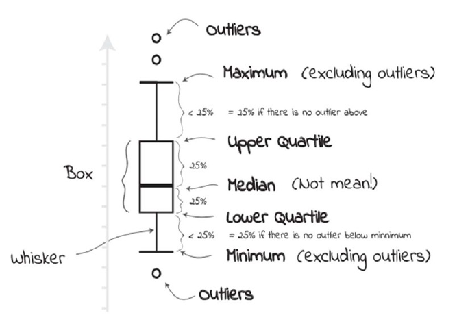

There are several methods to screen for outliers in a dataset, ranging from graphical techniques to statistical tests. Here are some commonly used methods:

Box Plots (Box-and-Whisker Plots):  
Box plots provide a visual representation of the distribution of data, including the identification of potential outliers. In a box plot, outliers are typically shown as individual data points beyond the whiskers of the plot.

### Methods to screen for outliers in a dataset

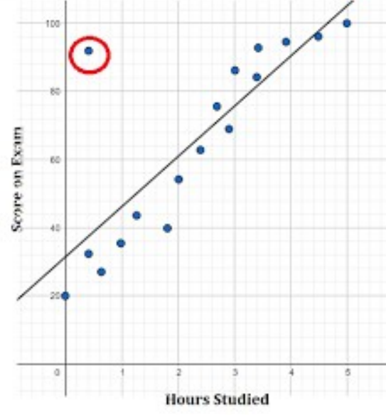

Scatterplots:

Scatterplots are particularly useful for identifying outliers in bivariate or multivariate data.

Outliers can appear as data points that are far from the main cluster of points in the scatterplot.

### Methods to screen for outliers in a dataset

Z-Scores:  
Z-scores (standard scores) measure how many standard deviations a data point is away from the mean. Data points with high absolute Z-scores (typically greater than 2 or 3) are often considered potential outliers.

IQR (Interquartile Range) Method:  
The IQR method involves calculating the interquartile range (IQR = Q3 – Q1) and then identifying values that fall below Q1 – 1.5 × IQR or above Q3 + 1.5 × IQR as potential outliers.

### Methods to screen for outliers in a dataset

Visual Inspection:

Sometimes, simple visual inspection of the data through histograms, QQ plots (quantile-quantile plots), or other visualization techniques can reveal the presence of outliers.

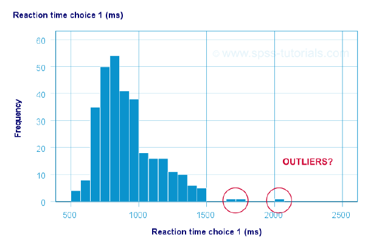

### Handling Outliers in Datasets

Handling outliers is an important step in data preprocessing to ensure they do not unduly influence the results of analysis or modeling. The approach depends on the nature of the data, the context of the analysis, and the specific objectives. Here are several methods for handling outliers:

**Data Truncation or Removal:**

Simply remove outliers from the dataset.

Should be done cautiously, especially if the outliers represent valid and important observations.

Appropriate when outliers are likely due to data entry or measurement errors.

**Data Transformation:**

Transforming the data can mitigate the impact of outliers.

Common transformations: logarithmic, square root, or inverse.

These compress the range of extreme values.

**Winsorization:**

Involves capping or limiting extreme values by replacing them with a specified percentile value.

Example: Replace values above the 95th percentile with the value at the 95th percentile.

**Imputation:**

For missing values (not extreme outliers), impute using methods like:

Mean imputation

Median imputation

Advanced methods (e.g., regression imputation).

### Handling Outliers in Datasets

**Robust Statistics:**

Use statistical methods less sensitive to outliers.

Examples:

Replace mean with median.

Use interquartile range (IQR) instead of standard deviation.

**Model-Based Approaches:**

In predictive modeling, use algorithms less sensitive to outliers.

Examples: robust regression methods, ensemble methods (e.g., random forests).

**Domain Knowledge:**

Rely on domain expertise to interpret outliers.

What looks like an outlier may actually be an important and valid data point.

**Reporting and Transparency:**

Clearly document how outliers were handled.

Ensures reproducibility and interpretability of results.

### Practice Datasets

[figure not shown]

Practice Statistics Using the following Datasets

Suggested Datasets:

https://github.com/msfasha/307102-Descriptive-Statistics-for-Business/blob/main/Practical/additional/useful_datasets.md

Suggested Analysis Scenario:

https://github.com/msfasha/307102-Descriptive-Statistics-for-Business/blob/main/Practical/additional/superstore_analysis_scenario.md